# Scripting in Abaqus with abapys

## 9.2 Plot Output

In contrast to variable selection, plotting FieldOutput or HistoryOutput variables can be more cumbersome. There are some restrictions as hinted below, but much can already be achieved with the `PlotOutput()` function.

Plots can either be created for distinct elements by specifying their label(s) or whole element sets. When only defining $y$-values, the variable is plotted over simulation time. An example for plotting the HistoryOutput is shown in code 9.2 and in figure 9.2.[^18] It is also possible to plot one OutputVariable over another (see code 9.3).

Code 9.2: Plotting HistoryOutput over time.

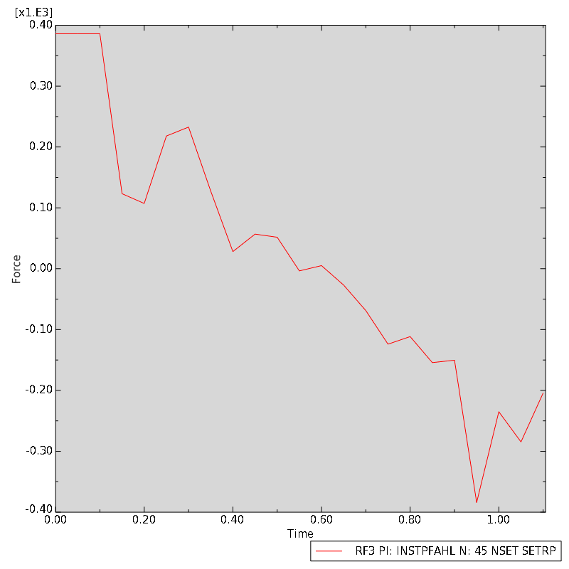

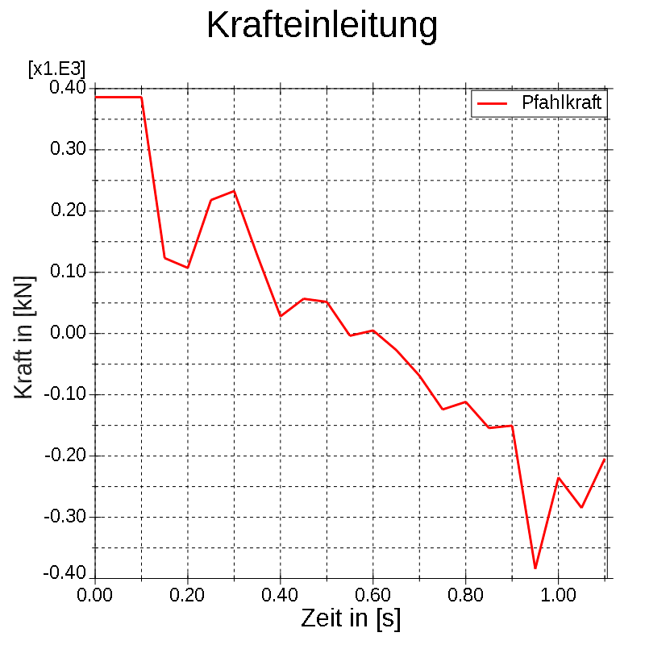

```python
PlotOutput(session=session, odbname=odbname, yvar=(['instPfahl', 'RF3']),
   ylabel='Kraft in [kN]', xlabel='Zeit in [s]', titel='Krafteinleitung',
   legendeneintraege=['Pfahlkraft']);
```

Figure 9.2: Plotting an OutputVariable does the job (left hand side) but is visually not as appealing as the resuluts produced with PlotOutput(). It is also straightforward to plot one or multiple curves over each other with PlotOutput().

Although multiple data points can be chosen as $y$-values, only one data set for $x$-values is allowed.

Code 9.3: Plotting FieldOutput over another FieldOutput.

```python
PlotOutput(session=session, odbname=odbname, yvar=(['instPfahl', 'RF3']),
   xvar=('U', 'U3'), xvarposition=('INSTPFAHL.SETRP'), xlabel='Weg in [m]',
   titel='Kraftverlauf', posxdir=False, legendeneintraege=['Pfahlkraft']);
```

Abaqus requires the $x$-values to be monotonic increasing when plotting one OutputVariable over another.

It is possible to beautify the plot by specifying label descriptions, title and legend entries (to `xlabel`/`ylabel`, `titel` and `legendeneintraege` respectively). Defining custom legend entries internally calls `PlotLegendeFormatieren()`, which in turn applies additional modifications (line thickness and legend position). So it is recommended to always use custom legend entries for readability and consistent style.

`PlotOutput()` requires a reference to the current `session`, the name of the output database (`odbname`) and a definition of the variable to plot passed to `yvar`.

To plot HistoryOutput data, either use `yvar=([<instance_name>, <variable_name>])` if the correct HistoryOutput can be identified or use `yvar=(<output_name>)` by specifying the complete output name. No position should be passed when using HistoryOutput data (i. e. `yvarposition=[]` if `yvar` represents a HistoryOutput). This also applies to `xvar` if used as a HistoryOutput.

`PlotOutput()` also has the following optional arguments with the given default values

- `ylabel=''` and `xlabel=''` to add a label to the $y$-axis or $x$-axis respectively,
- `posydir=True` and `posxdir=True` to increase values upwards/to the right (if `True`) or downwards/to the left with inverted axes (if `False`) respectively,
- `ylimit=[]` and `xlimit=[]` to define the limits of the $y$-axis and $x$-axis respectively,
- `titel=''` to give a title to the current plot,
- `legendeneintraege=[]` to add a legend entry for each data set to be plotted and
- `plothinzufuegen=False` to clear the current plot and create a new one (if `False`) or add the data to the current plot (if `True`).